# Forecasting Monthly Marriages

Carlota Marto 20241729, Francisca Teixeira 20241702, Inês Caseiro 20241780

2026-05-17

## 1. Introduction

This project analyzes and forecasts **monthly marriages in Queensland, Australia**, using the Box-Jenkins methodology (ARIMA/SARIMA).  
The dataset is sourced from the Queensland Government Open Data portal ([Marriages by Month](https://www.data.qld.gov.au/dataset/marriages-by-month)), which provides official monthly counts of marriages registered across the state.

The objective of this analysis is to identify trends and seasonal patterns in the number of marriages, fit a suitable SARIMA model, and produce reliable forecasts for the next 12 months.  
These forecasts can provide insights for government planning, service provision, and understanding social trends related to marriage in Queensland.

Session -> Set Working Directory as the directory where this file is currently in the computer.

```r
# Define the correct path for the CSV file
file_path <- "marriages_queensland/combined_file.csv"

# Load the CSV file
data <- read.csv(file_path)

# Create a Date column from Year and Month
data <- data %>%
  mutate(Date = yearmonth(paste(year, Month, sep = "-"))) %>%
  arrange(Date)

# Convert to tsibble
data_ts <- data %>%
  select(Date, Marriages) %>%
  as_tsibble(index = Date)

# Show the first 10 rows of the dataset
kable(head(data_ts, 10), caption = "First 10 rows of Monthly Marriages Data")
```

First 10 rows of Monthly Marriages Data

| Date | Marriages |
| --- | --- |
| 2010 jan | 1389 |
| 2010 fev | 1426 |
| 2010 mar | 2313 |
| 2010 abr | 2378 |
| 2010 mai | 2449 |
| 2010 jun | 1625 |
| 2010 jul | 1671 |
| 2010 ago | 2102 |
| 2010 set | 3313 |
| 2010 out | 4345 |

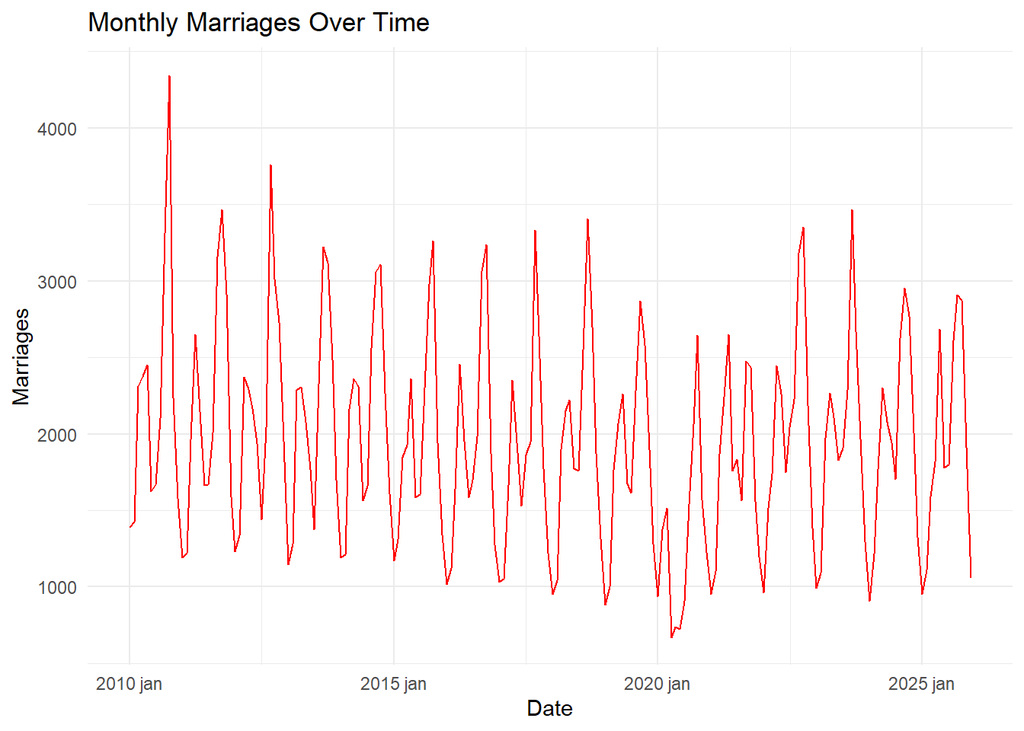

```r
data_ts %>%
  ggplot(aes(x = Date, y = Marriages)) +
  geom_line(color="red") +
  labs(title="Monthly Marriages Over Time", x="Date", y="Marriages") +
  theme_minimal()
```

```r
data_train <- data_ts%>%
  filter(year(Date) <= 2020)
data_train
```

```
## # A tsibble: 132 x 2 [1M]
##        Date Marriages
##       <mth>     <dbl>
##  1 2010 jan      1389
##  2 2010 fev      1426
##  3 2010 mar      2313
##  4 2010 abr      2378
##  5 2010 mai      2449
##  6 2010 jun      1625
##  7 2010 jul      1671
##  8 2010 ago      2102
##  9 2010 set      3313
## 10 2010 out      4345
## # ℹ 122 more rows
```

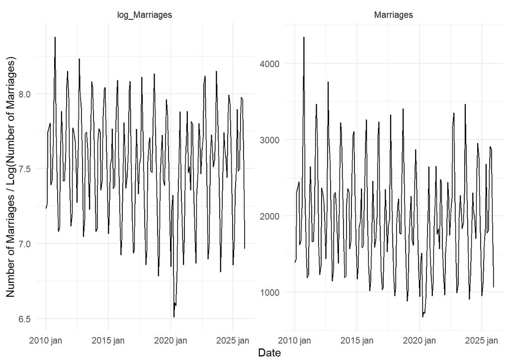

```r
data %>%
  mutate(log_Marriages = log(Marriages)) %>%  # Log transform the 'Marriages' column
  pivot_longer(cols = c(Marriages, log_Marriages), names_to = "Transformation", values_to = "Value") %>%  # Reshape data to long format
  ggplot(aes(x = Date, y = Value)) +  # Plot Date vs the transformed or original 'Marriages'
  geom_line() +
  facet_wrap(~ Transformation, scales = "free_y") +  # Facet by Transformation (original vs log-transformed)
  theme_minimal() +
  labs(y = 'Number of Marriages / Log(Number of Marriages)', x = 'Date')
```

As the variance is not constant over time, we need to stabilize it. For that, we will use the Box-Cox transformation with the guerrero method for finding lambda.

```r
lambda <- data_train %>%
  features(Marriages, features = guerrero) %>%
  pull(lambda_guerrero)
lambda
```

```
## [1] 0.4751842
```

```r
data_train <- data_train %>%
  mutate(TransformedMarriages = box_cox(Marriages, lambda))
```

# Stationarity

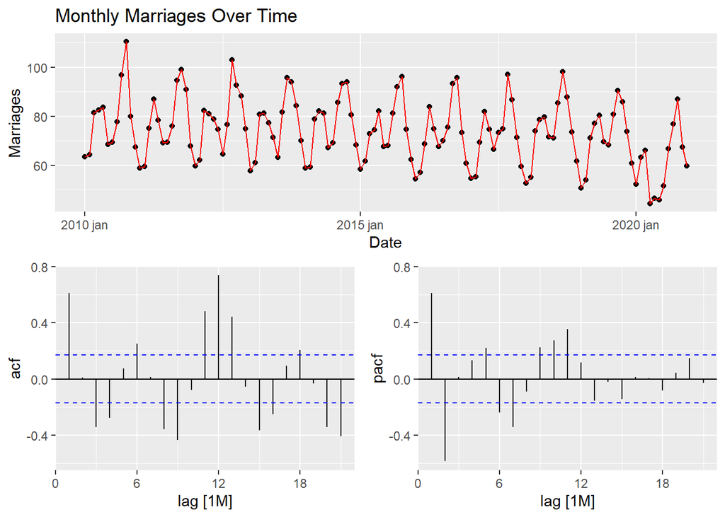

```r
data_train %>%
  gg_tsdisplay(y = TransformedMarriages, plot_type = "partial") +
  geom_line(color="red") +
  labs(title="Monthly Marriages Over Time", x="Date", y="Marriages")
```

```r
summary(ur.df(data_train$TransformedMarriages,type = "drift" ,lags = 16))
```

```
##
## ###############################################
## # Augmented Dickey-Fuller Test Unit Root Test #
## ###############################################
##
## Test regression drift
##
##
## Call:
## lm(formula = z.diff ~ z.lag.1 + 1 + z.diff.lag)
##
## Residuals:
##      Min       1Q   Median       3Q      Max
## -28.4304  -2.5151  -0.0017   2.7480   9.8076
##
## Coefficients:
##               Estimate Std. Error t value Pr(>|t|)
## (Intercept)  -25.47418   15.65227  -1.628 0.106873
## z.lag.1        0.32699    0.20763   1.575 0.118550
## z.diff.lag1   -0.81873    0.23837  -3.435 0.000875 ***
## z.diff.lag2   -0.76027    0.23951  -3.174 0.002013 **
## z.diff.lag3   -0.64641    0.25721  -2.513 0.013614 *
## z.diff.lag4   -0.73174    0.26291  -2.783 0.006470 **
## z.diff.lag5   -0.82091    0.27139  -3.025 0.003184 **
## z.diff.lag6   -0.78124    0.26787  -2.917 0.004398 **
## z.diff.lag7   -0.81098    0.24656  -3.289 0.001401 **
## z.diff.lag8   -0.88174    0.23728  -3.716 0.000339 ***
## z.diff.lag9   -0.76241    0.21797  -3.498 0.000710 ***
## z.diff.lag10  -0.77961    0.20689  -3.768 0.000282 ***
## z.diff.lag11  -0.49593    0.20228  -2.452 0.016007 *
## z.diff.lag12  -0.04628    0.18194  -0.254 0.799748
## z.diff.lag13  -0.13345    0.16118  -0.828 0.409749
## z.diff.lag14  -0.10653    0.14317  -0.744 0.458604
## z.diff.lag15  -0.31673    0.12467  -2.540 0.012657 *
## z.diff.lag16  -0.26086    0.10679  -2.443 0.016388 *
## ---
## Signif. codes:  0 '***' 0.001 '**' 0.01 '*' 0.05 '.' 0.1 ' ' 1
##
## Residual standard error: 5.176 on 97 degrees of freedom
## Multiple R-squared:  0.8216, Adjusted R-squared:  0.7903
## F-statistic: 26.28 on 17 and 97 DF,  p-value: < 2.2e-16
##
##
## Value of test-statistic is: 1.5748 2.5471
##
## Critical values for test statistics:
##       1pct  5pct 10pct
## tau2 -3.46 -2.88 -2.57
## phi1  6.52  4.63  3.81
```

As test-statistic (1.5748) does not belong to the critical region (tobs < -2.88), we fail to reject H0. There is statistical evidence of non-stationarity at 5% significance level. / We will apply a seasonal difference.

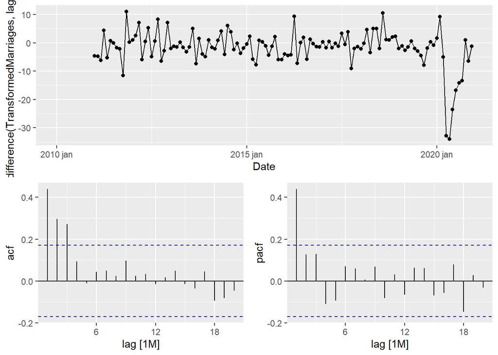

```r
data_train %>%
  gg_tsdisplay(difference(TransformedMarriages, lag = 12), plot_type = "partial")
```

```r
summary(ur.df(na.omit(difference(data_train$TransformedMarriages, lag = 12)), type = "drift", lags = 1))
```

```
##
## ###############################################
## # Augmented Dickey-Fuller Test Unit Root Test #
## ###############################################
##
## Test regression drift
##
##
## Call:
## lm(formula = z.diff ~ z.lag.1 + 1 + z.diff.lag)
##
## Residuals:
##      Min       1Q   Median       3Q      Max
## -31.2353  -2.6545   0.0433   2.7853  16.5297
##
## Coefficients:
##             Estimate Std. Error t value Pr(>|t|)
## (Intercept) -0.85522    0.57177  -1.496    0.137
## z.lag.1     -0.48981    0.09790  -5.003 2.05e-06 ***
## z.diff.lag  -0.12865    0.09265  -1.389    0.168
## ---
## Signif. codes:  0 '***' 0.001 '**' 0.01 '*' 0.05 '.' 0.1 ' ' 1
##
## Residual standard error: 5.911 on 115 degrees of freedom
## Multiple R-squared:  0.2932, Adjusted R-squared:  0.2809
## F-statistic: 23.85 on 2 and 115 DF,  p-value: 2.167e-09
##
##
## Value of test-statistic is: -5.0029 12.5155
##
## Critical values for test statistics:
##       1pct  5pct 10pct
## tau2 -3.46 -2.88 -2.57
## phi1  6.52  4.63  3.81
```

As the test-statistic (-5.0029) belongs to the critical region (tobs < -2.88), we reject H0. There is statistical evidence of stationarity at 5% significance level.

# Model identification

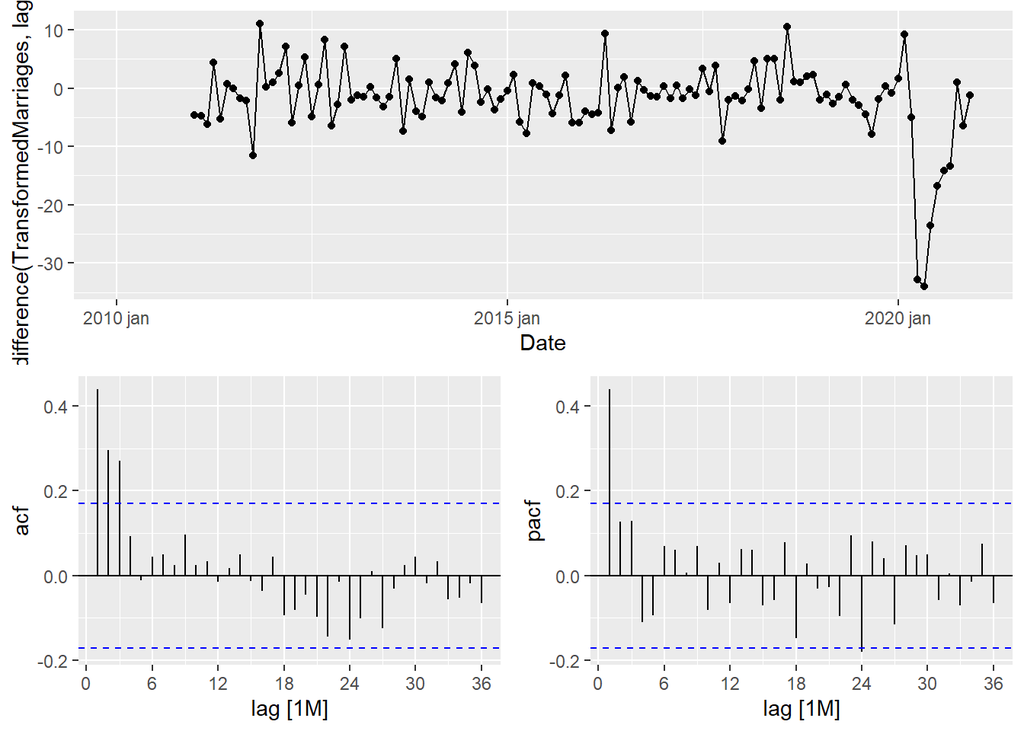

```r
data_train %>%
  gg_tsdisplay(difference(TransformedMarriages, lag = 12), plot_type = "partial", lag = 36)
```

Possible models: SARIMA(1,0,3) (2,1,0)12, SARIMA(1,0,1) (0,1,0)12